# Le vélo à Paris : comprendre et prévoir le trafic cyclable

## 7.2 Significativité, causalité, inversibilité

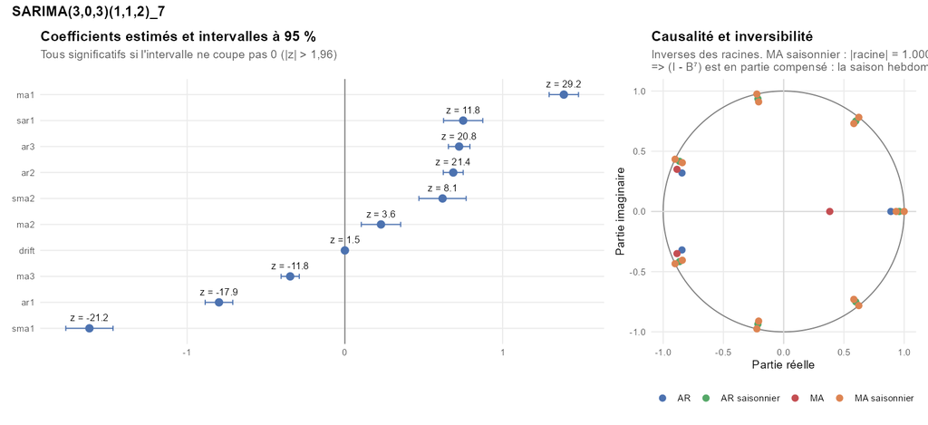

Coefficients (intervalles à 95 %) et inverses des racines des polynômes.

Tous les coefficients ARMA sont significatifs ($|z| > 1{,}96$) ; seule la dérive ne l’est pas (p = 0,14). Les racines des polynômes AR sont hors du disque unité : le modèle est causal. Mais **le polynôme MA saisonnier $1 - 1{,}62\,z + 0{,}62\,z^2 = (1 - z)(1 - 0{,}62\,z)$ a une racine unité**.

**Important**

**Diagnostic de sur-différenciation.** Le MA saisonnier compense la différence $(I - B^7)$ : $(I - B^7)$ suivi de $(1 - \Theta B^7)$ avec $\Theta \approx 1$ revient à ne pas différencier. Toutes les variantes essayées confirment ce diagnostic : avec $D = 1$, on trouve toujours $\Theta \approx -0{,}99$, et avec $D = 0$, un AR saisonnier égal à 1. **La saison hebdomadaire est donc déterministe** : le profil de la semaine ne dérive pas, il est le même chaque semaine à un bruit près. Conséquence pour le SARIMAX : on traitera la semaine par des indicatrices de jour, sans différence saisonnière.

## 7.3 Décomposition de Wold et intervalles de prévision

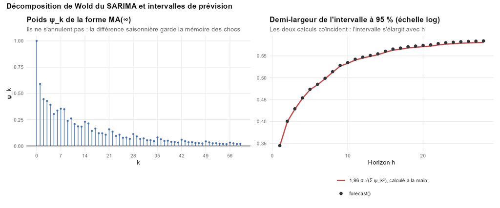

Poids ψ_k de la forme MA(∞) et demi-largeur de l’intervalle de prévision, calculée à la main et par forecast().

## 7.4 Diagnostic des résidus

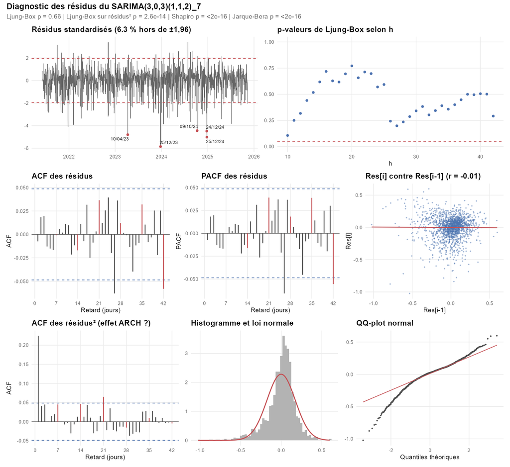

Diagnostic des résidus : chronogramme, p-valeurs de Ljung-Box, ACF, PACF, ACF des carrés, histogramme, QQ-plot.

| Test | H0 | Statistique | p-valeur |
| --- | --- | --- | --- |
| Ljung-Box (h = 21, fitdf = 9) | résidus non corrélés | 9,53 | 0.66 |
| Ljung-Box résidus² (h = 21) | pas d’effet ARCH | 111,47 | 2.6e-14 |
| Shapiro-Wilk | normalité | 0,94 | < 2e-16 |
| Jarque-Bera | normalité | 882,31 | < 2e-16 |

Les résidus sont **non corrélés** (Ljung-Box avec `fitdf` = p + q + P + Q). Ils ne sont **pas gaussiens** (queues épaisses, asymétrie à gauche), et leurs carrés sont corrélés. Test de sur-ajustement : un terme AR de plus n’est pas significatif (p = 0,22). Un terme MA de plus est significatif mais dégrade nettement le BIC : le modèle est déjà riche, et ses paramètres se compensent entre eux. C’est un autre symptôme de la quasi-simplification AR / MA saisonnière.

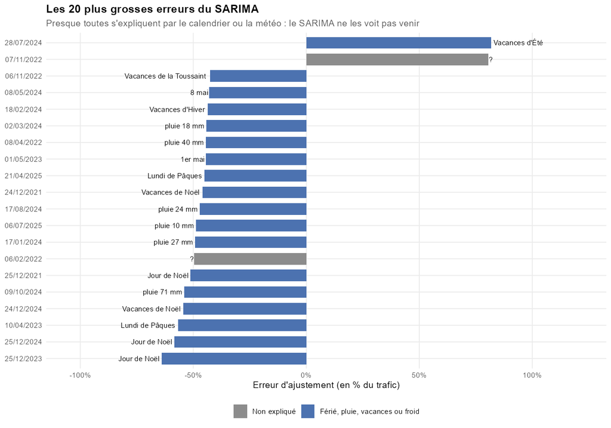

Les 20 plus grosses erreurs du SARIMA.

Les plus grosses erreurs tombent presque toutes un jour férié, un jour de forte pluie ou pendant les vacances : le SARIMA ne peut pas les anticiper.

## 7.5 Effet ARCH

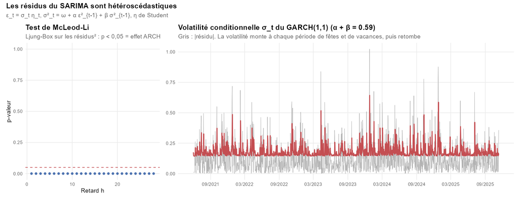

Test de McLeod-Li et GARCH(1,1) ajusté sur les résidus.

Les résidus au carré sont autocorrélés : il y a un **effet ARCH**. Un GARCH(1,1) à innovations de Student ajusté sur les résidus donne $\alpha = 0,35$ et $\beta = 0,24$. La volatilité conditionnelle monte à chaque période de fêtes. Cette hétéroscédasticité vient surtout d’effets de calendrier mal pris en compte, pas d’une volatilité « financière » : c’est le calendrier qu’il faut modéliser.

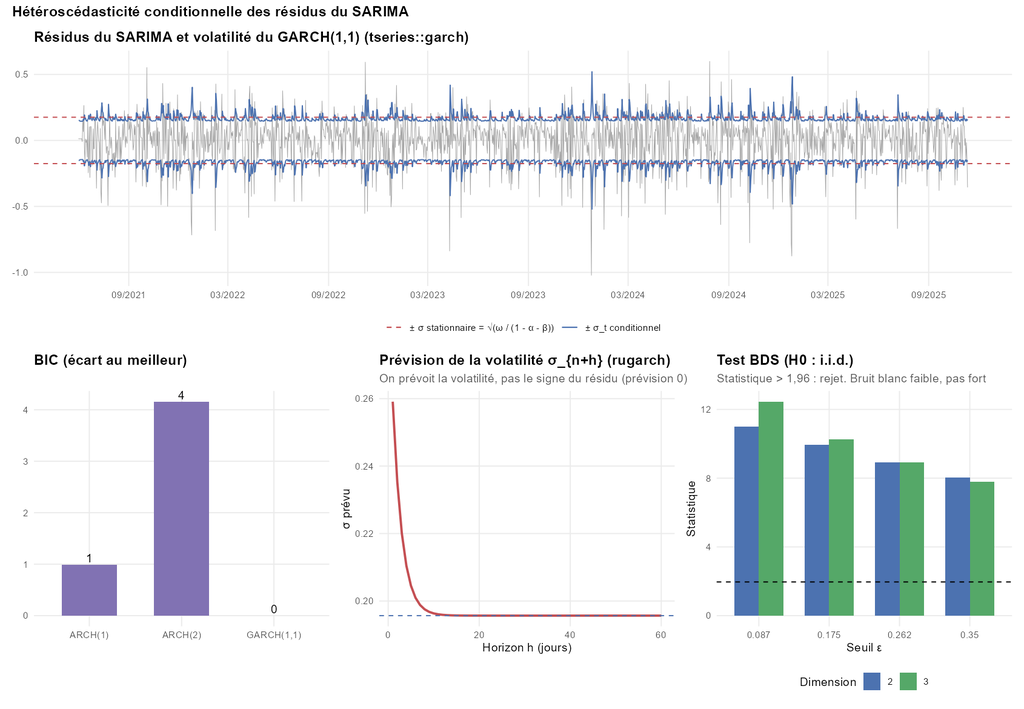

GARCH complet : volatilité conditionnelle et stationnaire (tseries::garch), choix par BIC, prévision de la volatilité (rugarch), test BDS.

On compare ARCH(1), ARCH(2) et GARCH(1,1) avec `tseries::garch`. Le BIC retient le **GARCH(1,1)**. Comme $\alpha + \beta = 0,52 < 1$, la variance stationnaire existe : $\sigma = \sqrt{\omega / (1 - \alpha - \beta)} = 0,176$, très proche de l’écart-type des résidus. La prévision de la volatilité revient vers ce niveau en une dizaine de jours. On prévoit la volatilité, pas le signe du résidu, dont la prévision vaut 0.

**Bruit blanc faible, pas fort.** Les résidus passent le test de Ljung-Box : ils sont non corrélés, donc forment un bruit blanc faible. Mais leurs carrés sont corrélés, et le **test BDS** (H0 : i.i.d.) rejette très nettement (statistiques de 7,8 à 12,5, p < $10^{-14}$). Ce n’est donc **pas un bruit blanc fort**. C’est l’exemple concret de la différence entre non-corrélation et indépendance.

Enfin, 93,8 % des observations tombent dans la bande « valeurs ajustées ± 1,96 σ̂ », un peu moins que les 95 % attendus : c’est l’effet des queues épaisses.

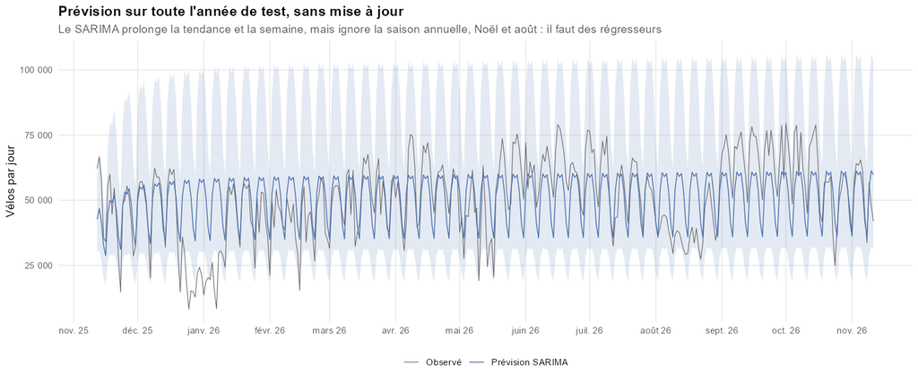

Prévision du SARIMA sur toute l’année de test, sans mise à jour.

## 7.6 Retour à l’échelle des vélos

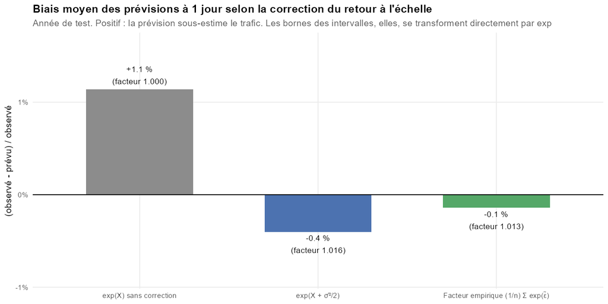

Biais des prévisions à 1 jour selon la correction appliquée au retour du log.

Si $X = \log Z$ avec une erreur $\mathcal N(0, \sigma^2)$, alors $E[Z] = e^{\hat X + \sigma^2/2}$ : la prévision naïve $e^{\hat X}$ sous-estime. Sur l’année de test, elle sous-estime de 1,1 %. La correction log-normale $e^{\hat\sigma^2/2}$ (facteur 1,016) ramène le biais à -0,4 %. Le facteur empirique $\frac1n\sum e^{\tilde\varepsilon_t}$, plus adapté à des résidus non gaussiens, le ramène à -0,1 %. Les bornes des intervalles, elles, se transforment directement par l’exponentielle. Toutes les prévisions du projet utilisent la correction (`biasadj = TRUE`).

## 7.7 L’alternative (d, D) = (1, 1)

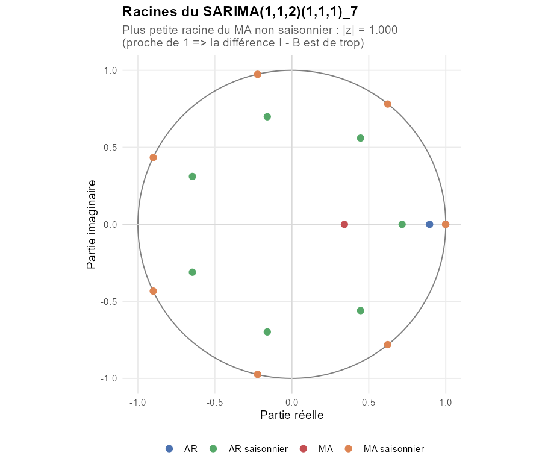

Racines du SARIMA doublement différencié.

On essaie aussi de différencier deux fois. Le meilleur modèle par BIC est le SARIMA(1,1,2)(1,1,1)₇. Son polynôme MA a une racine de module **1,000** et son MA saisonnier vaut $\Theta \approx -0{,}99$ : **les deux différences sont compensées par des racines unité du MA**. C’est la signature d’une double sur-différenciation, cohérente avec les tests de la partie 6 ($d = 0$). Sans dérive possible (d + D = 2), ce modèle est aussi évalué hors échantillon en partie 10.

## 7.8 Simulation du modèle estimé

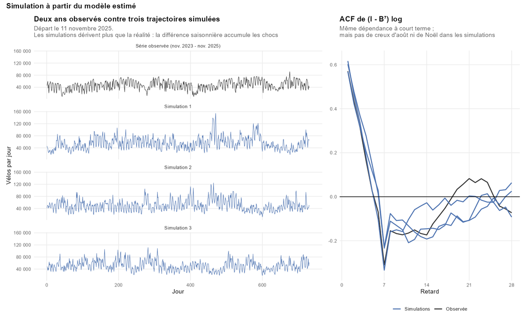

Deux années observées contre trois trajectoires simulées par le SARIMA.

Simuler le modèle estimé est un bon test de vraisemblance visuelle. Les trajectoires ont le bon niveau, la bonne semaine et la même ACF à court terme. Mais elles n’ont ni creux d’août ni creux de Noël, et elles dérivent plus que la réalité, car la différence saisonnière accumule les chocs. C’est une autre façon de voir ce que le SARIMA ne capture pas.

# 8 Modèle SARIMAX

## 8.1 Spécification

D’après les parties 6 et 7, on écrit une **régression à erreurs SARIMA** :

$$\log X_t = a + b\,t + \underbrace{\textstyle\sum_j \delta_j \mathbb 1_{\{\text{jour}_t = j\}}}_{\text{semaine}} + \underbrace{\textstyle\sum_{k=1}^{K} \alpha_k \sin\tfrac{2\pi k t}{365{,}25} + \beta_k \cos\tfrac{2\pi k t}{365{,}25}}_{\text{saison annuelle}} + \gamma' c_t + \eta' m_t + u_t,$$

où $c_t$ regroupe le calendrier (férié en semaine, pont, vacances de Noël, d’été et autres, Jeux olympiques), $m_t$ la météo du jour (température et son carré, $\log(1 + \text{pluie})$, vent) et $u_t$ suit un SARIMA$(p,0,q)(P,0,Q)_7$. Les ordres et le nombre d’harmoniques $K$ sont choisis par BIC.

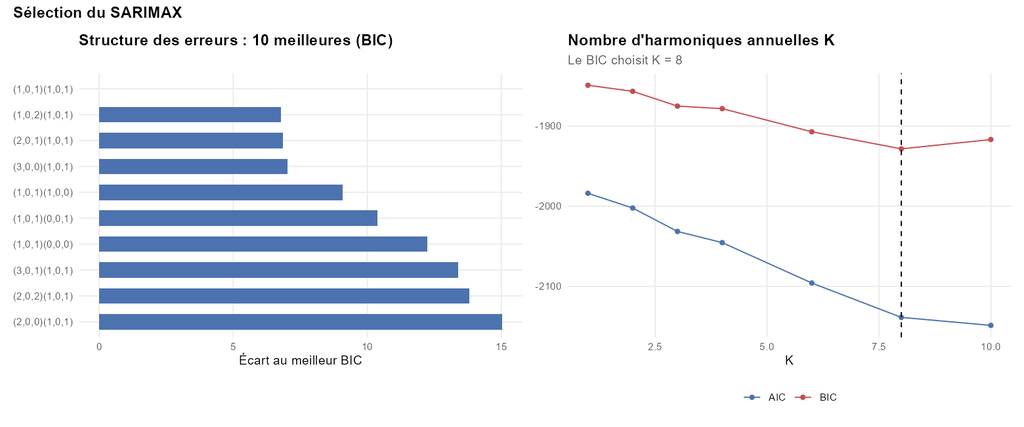

Sélection de la structure des erreurs et du nombre d’harmoniques.

## 8.2 Effets estimés

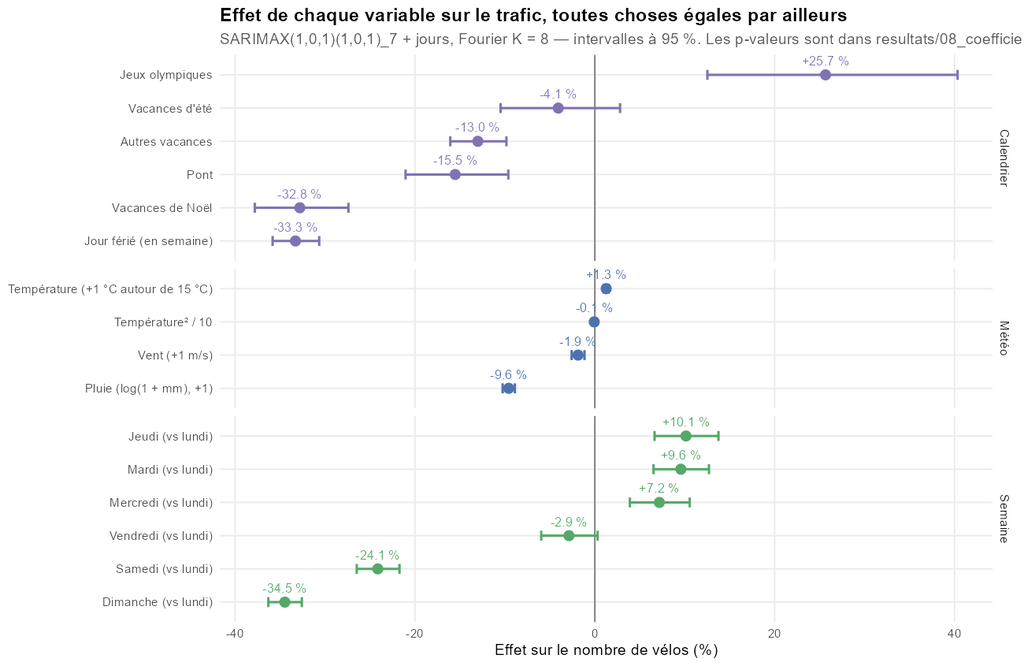

Effet de chaque variable, en %, avec intervalle à 95 %.

Chaque coefficient se lit comme un effet multiplicatif $e^{\beta} - 1$, toutes choses égales par ailleurs :

- un **jour férié** en semaine : -33 % ; un **pont** : -16 % ;
- les **vacances de Noël** : -33 %, les **autres vacances** : -13 % (l’été n’a pas d’effet propre une fois la saison annuelle prise en compte) ;
- les **Jeux olympiques** : +26 % ;
- **+1 °C** : +1.3 % ; **+1 m/s de vent** : -1,9 % ;
- le dimanche compte 34 % de vélos de moins qu’un lundi.

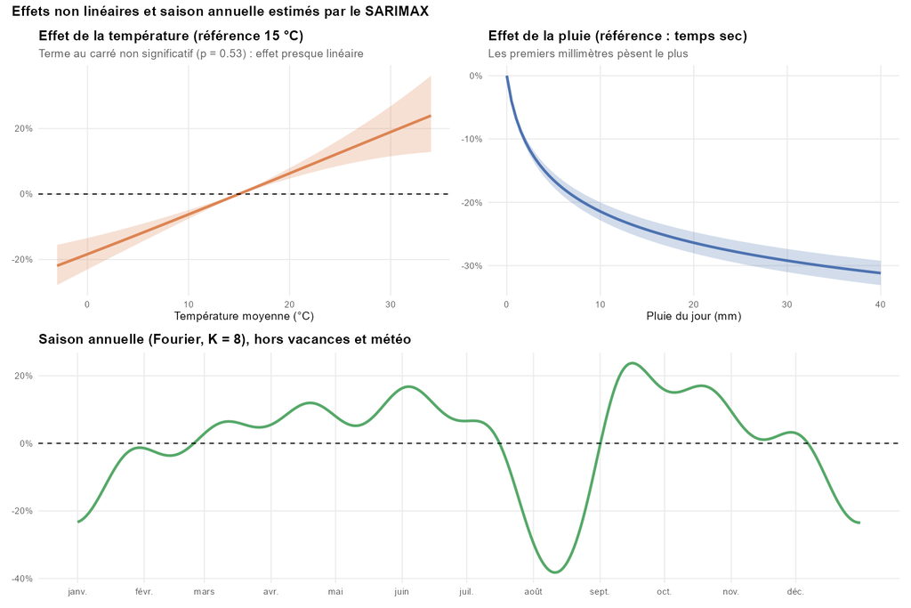

Effet de la température, de la pluie et saison annuelle estimés.

L’effet de la pluie est concave : 2 mm font déjà perdre environ 10 % de trafic, 20 mm environ 26 %. Une fois la météo et les vacances retirées, la saison annuelle fait apparaître le creux d’août et le pic de rentrée de septembre.

## 8.3 Utilité de chaque bloc : rapports de vraisemblance

| Bloc retiré | ddl | LR | p-valeur | BIC sans le bloc | BIC complet |
| --- | --- | --- | --- | --- | --- |
| Météo | 4 | 695,1 | < 2e-16 | -1 262,9 | -1 928,4 |
| Calendrier | 6 | 519,8 | < 2e-16 | -1 453,0 | -1 928,4 |
| Saison annuelle (Fourier) | 16 | 184,8 | < 2e-16 | -1 861,9 | -1 928,4 |
| Jours de la semaine | 6 | 66,0 | 2.7e-12 | -1 906,7 | -1 928,4 |

Retirer n’importe quel bloc dégrade très nettement la vraisemblance. La météo est le bloc le plus important, devant le calendrier. Le SARIMA de la partie 7 n’est pas emboîté (il différencie), mais on peut comparer les variances d’erreur à un jour, qui sont sur la même échelle : l’écart-type passe de 0,176 à 0,124, soit **30 % d’erreur en moins**.

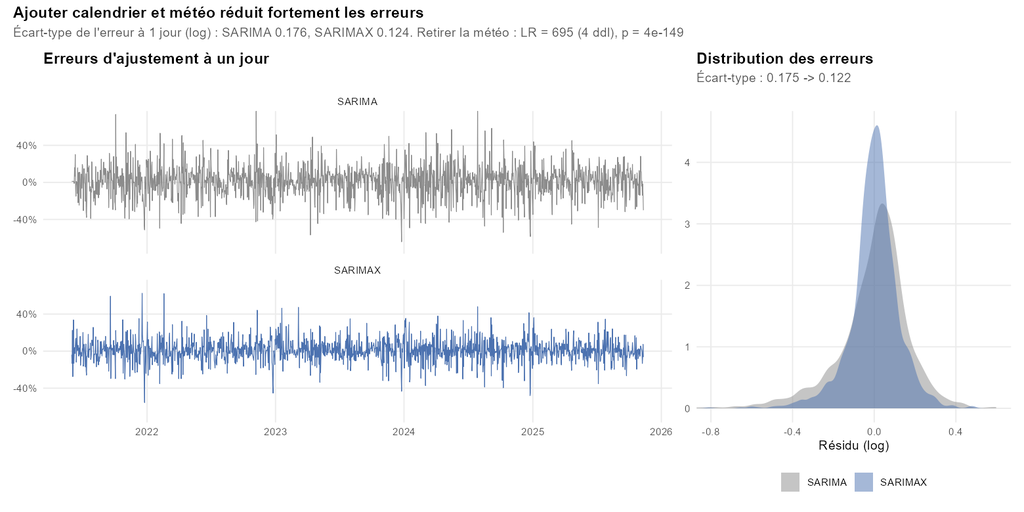

Erreurs d’ajustement du SARIMA et du SARIMAX.

## 8.4 Diagnostic

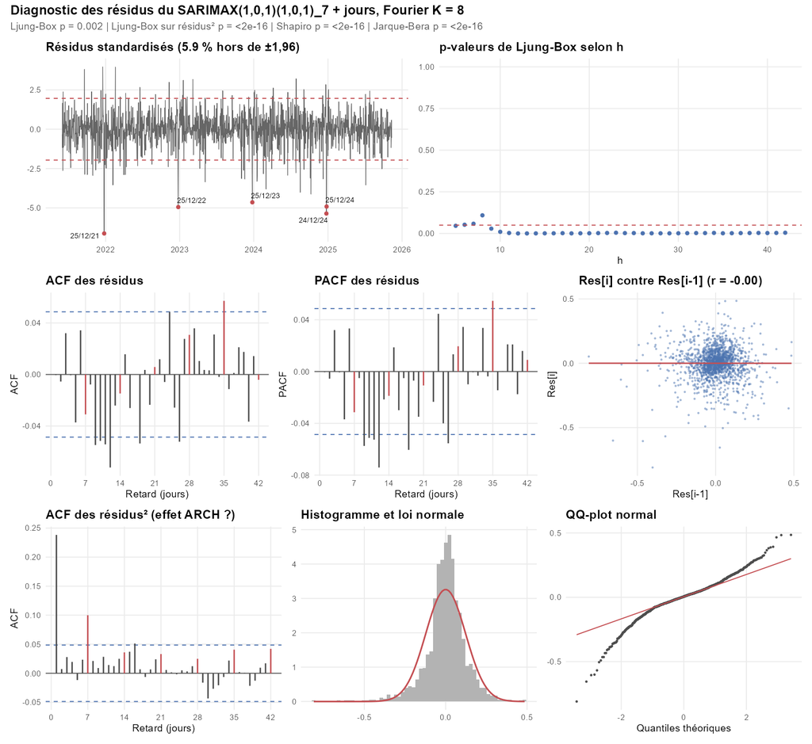

Diagnostic des résidus du SARIMAX.

| Test | H0 | Statistique | p-valeur |
| --- | --- | --- | --- |
| Ljung-Box (h = 21, fitdf = 4) | résidus non corrélés | 38,72 | 0.002 |
| Ljung-Box résidus² (h = 21) | pas d’effet ARCH | 127,30 | <2e-16 |
| Shapiro-Wilk | normalité | 0,95 | <2e-16 |
| Jarque-Bera | normalité | 1 223,30 | <2e-16 |

Une petite autocorrélation résiduelle subsiste. Le Ljung-Box à 21 retards rejette la blancheur, car l’échantillon est très grand et le test détecte des écarts minimes : les autocorrélations restent faibles en valeur absolue, comme le montre l’ACF. Les résidus restent non gaussiens, avec des queues épaisses dues à quelques journées exceptionnelles :

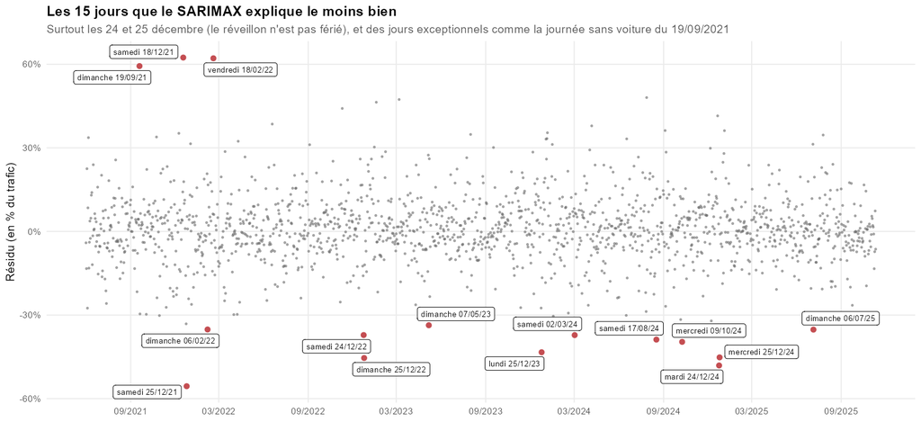

Les jours les moins bien expliqués.

## 8.5 Corrélations croisées et météo de la veille

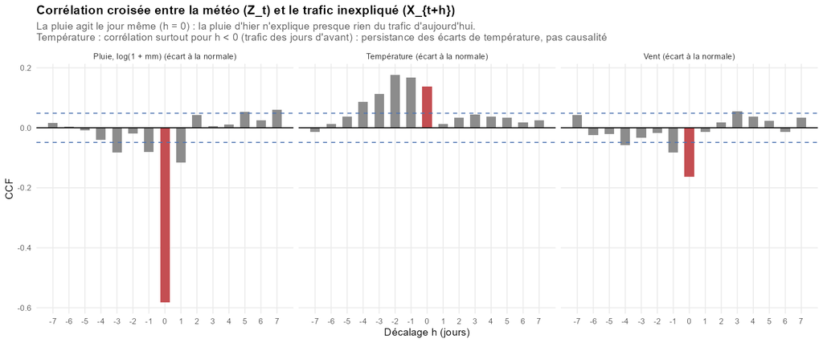

CCF entre l’écart de la météo à sa normale (Z_t) et le trafic inexpliqué par un SARIMAX sans météo (X_{t+h}).

La **CCF** croise la météo, prise en écart à sa normale de saison, avec les innovations d’un SARIMAX sans météo. La pluie agit **le jour même** (corrélation de −0,58 à $h = 0$, presque rien à $h = \pm 1$). Pour la température, la corrélation s’étale sur les jours précédents. Ce n’est pas un effet causal : les écarts de température durent plusieurs jours, et il faut se méfier de ces corrélations fallacieuses.

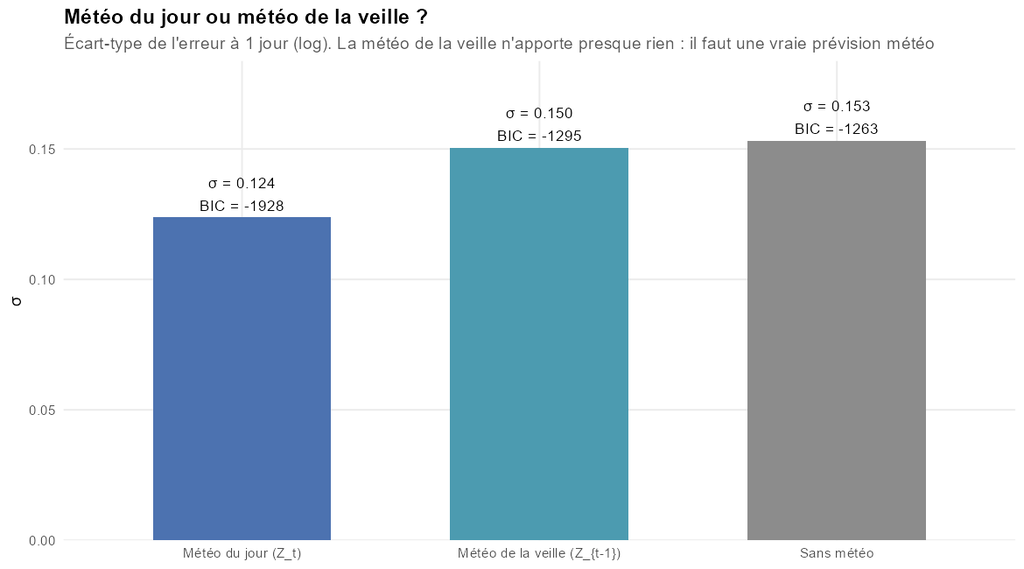

SARIMAX avec la météo du jour, la météo de la veille, ou sans météo.

Une parade classique au problème de la météo future inconnue consiste à **décaler** la variable exogène, en expliquant $X_t$ par $Z_{t-1}$. Sur nos données, cette solution ne fonctionne pas. Avec la météo de la veille, l’écart-type de l’erreur vaut 0,150, presque autant que sans météo (0,153), contre 0,124 avec la météo du jour. La pluie d’hier ne dit presque rien du trafic d’aujourd’hui : il faut une **vraie prévision météo**.

## 8.6 Réponse à la problématique : quelle part s’explique par quoi ?

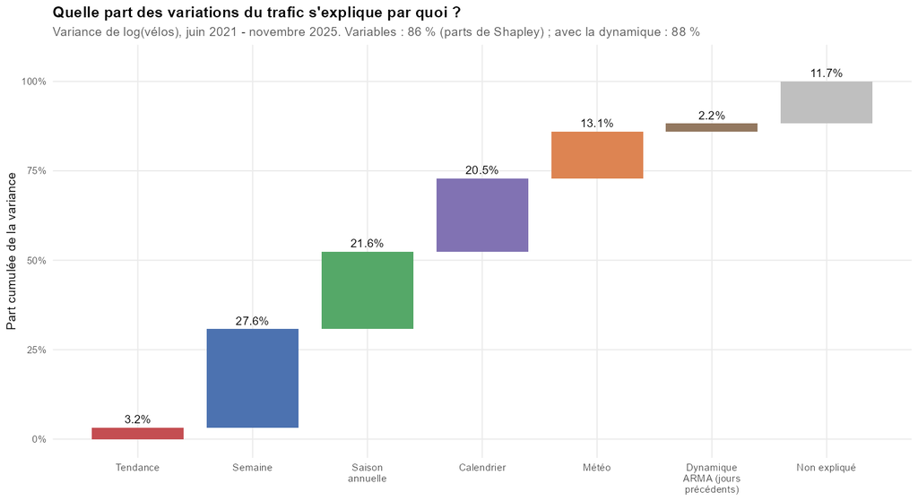

Décomposition de la variance de log(vélos) : parts de Shapley de chaque bloc, puis dynamique ARMA.

La part de variance d’un bloc dépend de l’ordre dans lequel on ajoute les blocs. On fait donc la moyenne sur tous les ordres possibles : ce sont les **valeurs de Shapley** du $R^2$.

| Bloc | Part de la variance |
| --- | --- |
| Tendance | 3,2 % |
| Semaine | 27,6 % |
| Saison annuelle | 21,6 % |
| Calendrier | 20,5 % |
| Météo | 13,1 % |
| Dynamique ARMA (jours précédents) | 2,2 % |
| Non expliqué | 11,7 % |

**Le calendrier au sens large (semaine, saison, fériés, vacances) explique environ 70 % des variations du trafic, la météo 13 %.** La tendance pèse peu à l’échelle journalière, et la mémoire propre de la série (l’ARMA) n’ajoute que 2,2 %. Il reste 12 % d’aléa.

# 9 Modèles concurrents

On met les SARIMA en concurrence avec des méthodes qui pondèrent le passé autrement : selon son éloignement (lissages exponentiels), sa ressemblance (blocs) ou via un réseau de neurones.

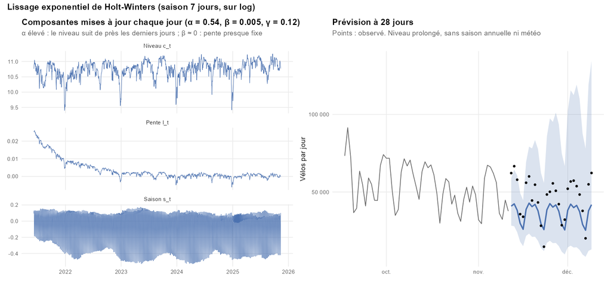

Lissage de Holt-Winters additif (sur log, saison 7).

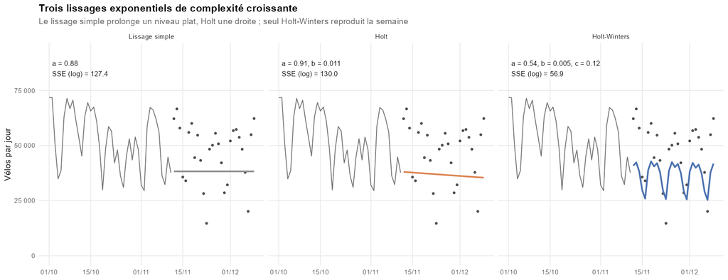

Lissage simple, Holt, Holt-Winters : trois niveaux de complexité.

Les trois lissages exponentiels s’emboîtent :

- le **lissage simple** estime un niveau, et sa prévision est plate ;
- **Holt** y ajoute une pente, donc une prévision en droite ;
- **Holt-Winters** y ajoute la saison.

Seul ce dernier reproduit la semaine : sa somme des carrés des erreurs à un pas est divisée par deux.

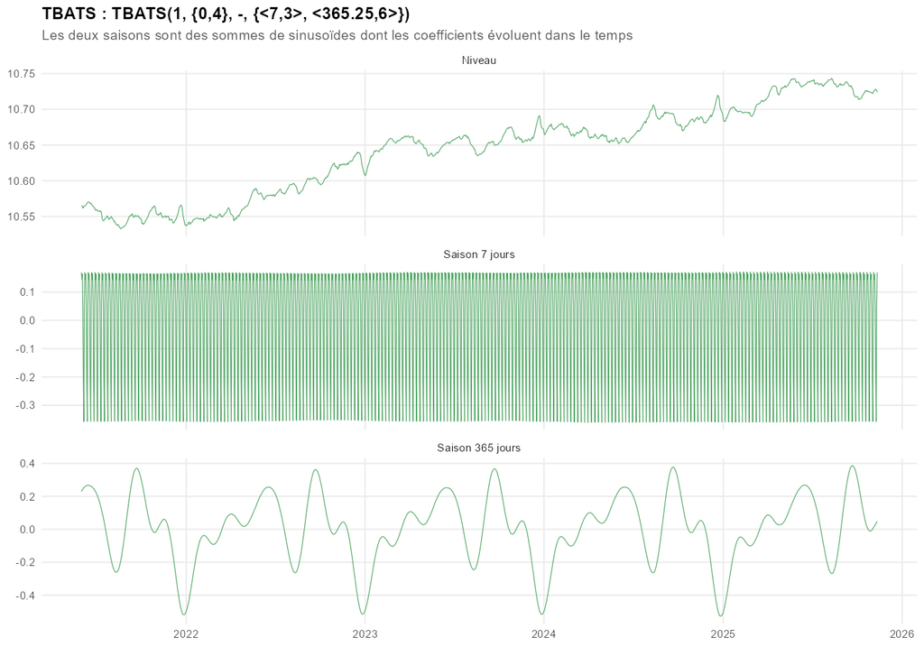

TBATS : deux saisons trigonométriques à coefficients évolutifs.

[figure not shown]

Prophet avec jours fériés, vacances et météo.

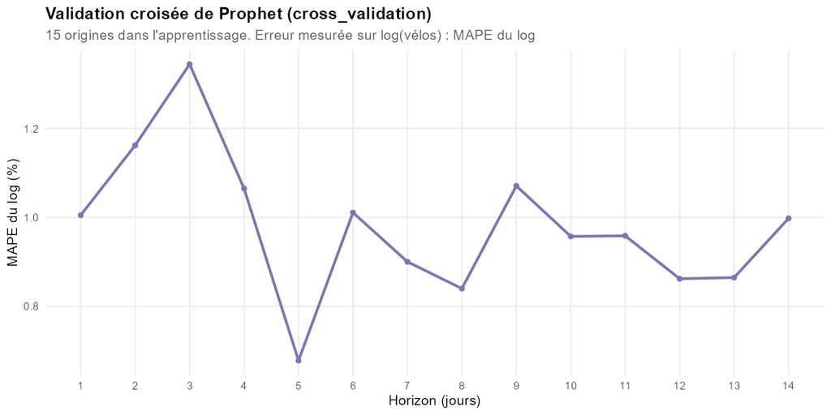

Validation croisée intégrée à Prophet (cross_validation).

La fonction `cross_validation` ré-estime Prophet sur une fenêtre qui s’agrandit, avec au moins deux ans de données et une nouvelle origine tous les 60 jours. Elle confirme une erreur stable entre 1 et 14 jours : Prophet ne dépend pas des derniers jours observés.

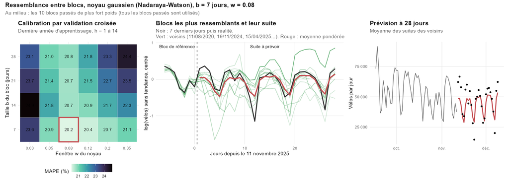

Ressemblance entre blocs : les 10 périodes passées les plus proches et leur suite.

Pour la **ressemblance entre blocs**, on utilise l’estimateur de Nadaraya-Watson. On retire la tendance, puis chaque bloc passé $B_i$ (finissant le même jour de la semaine que le bloc courant) reçoit un poids $W_i \propto k\big((B_{courant} - B_i)/w\big)$, avec un noyau $k$ gaussien. La prévision est la moyenne pondérée des suites de ces blocs. La taille du bloc $b$ et la fenêtre $w$ sont choisies par **validation croisée** sur la dernière année d’apprentissage : $b = 7$ jours, $w = 0,08$ (MAPE de validation 20,2 %).

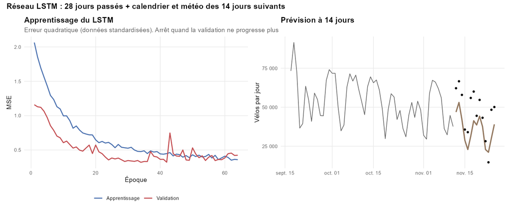

LSTM : courbes d’apprentissage et prévision.

Le **LSTM** reçoit la séquence des 28 derniers jours (trafic sans tendance et variables du jour) ainsi que le calendrier et la météo des 14 jours à prévoir, et il produit les 14 prévisions directement. Le **NNAR** est un perceptron à une couche cachée qui prend en entrée les retards de la série et les régresseurs ; c’est la moyenne de 20 réseaux.

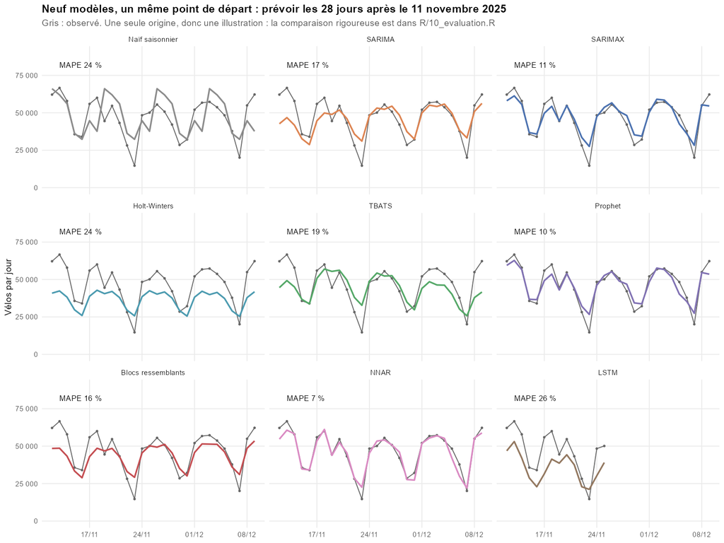

Les neuf modèles, depuis une même origine (illustration).

# 10 Évaluation des prévisions

## 10.1 Protocole

Les paramètres sont estimés une seule fois sur l’apprentissage. Chaque jour $o$ de l’année de test, on suppose connues les données jusqu’à $o$ et on prévoit $o+1, \dots, o+14$ : c’est une **validation croisée à origine glissante**. Les modèles dynamiques mettent leur état à jour sans être ré-estimés. Cela fait 352 origines × 14 horizons, soit près de 5 000 prévisions pour chacun des 14 modèles. Les 4 jours de coupure générale des compteurs sont exclus.

La **météo future** est inconnue au moment de prévoir. On encadre donc la réalité par deux versions du SARIMAX : « météo observée » (prévision météo parfaite) et « météo climatologique » (aucune information, météo moyenne de la saison).

## 10.2 Résultats

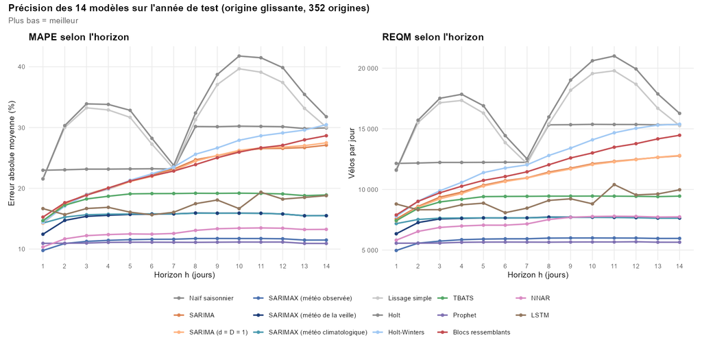

MAPE et REQM selon l’horizon.

Scores sur l’année de test, triés par MAPE moyen (tous horizons).

| Modèle | REQM (vélos) | MAPE (%) | MAPE h = 1 | MAPE h = 7 | MAPE h = 14 | Couverture 95 % |
| --- | --- | --- | --- | --- | --- | --- |
| Prophet | 5 645 | 11,1 | 10,9 | 11,1 | 10,9 | - |
| SARIMAX (météo observée) | 5 852 | 11,4 | 9,8 | 11,6 | 11,5 | 94 |
| NNAR | 7 274 | 12,7 | 10,3 | 12,6 | 13,2 | - |
| SARIMAX (météo de la veille) | 7 555 | 15,4 | 12,4 | 15,8 | 15,5 | 93 |
| SARIMAX (météo climatologique) | 7 621 | 15,6 | 14,3 | 15,8 | 15,5 | 88 |
| LSTM | 9 046 | 17,2 | 16,7 | 16,1 | 18,8 | - |
| TBATS | 9 189 | 18,5 | 14,7 | 19,1 | 18,9 | 94 |
| SARIMA (d = D = 1) | 10 976 | 22,9 | 14,2 | 22,9 | 27,5 | 94 |
| SARIMA | 11 030 | 22,9 | 14,6 | 23,2 | 27,1 | 94 |
| Blocs ressemblants | 11 856 | 23,1 | 15,3 | 22,8 | 28,7 | - |
| Holt-Winters | 12 591 | 24,0 | 14,4 | 23,5 | 30,5 | 94 |
| Naïf saisonnier | 13 871 | 26,6 | 23,0 | 23,2 | 29,9 | - |
| Lissage simple | 16 424 | 32,0 | 21,6 | 23,2 | 30,1 | - |
| Holt | 17 161 | 33,3 | 21,5 | 23,8 | 31,8 | - |

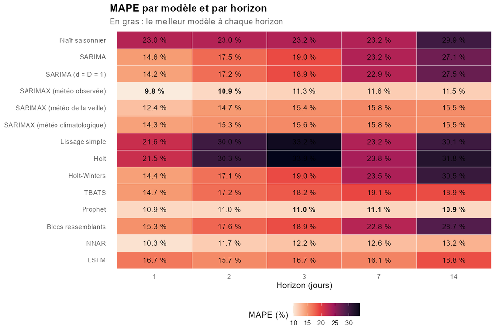

MAPE par modèle et par horizon.

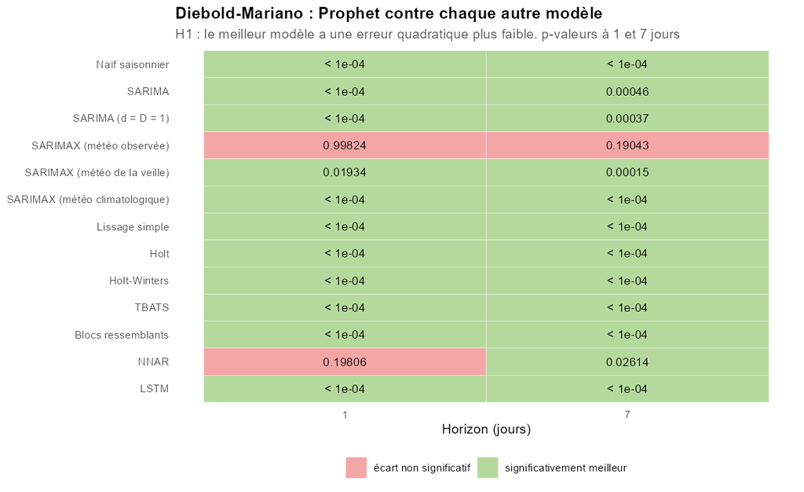

Test de Diebold-Mariano : le meilleur modèle contre chacun des autres.

Quatre enseignements :

- **Le calendrier et la météo font la différence.** Les trois modèles qui les utilisent (SARIMAX, Prophet, NNAR) se détachent nettement : de 11,1 % à 12,7 % d’erreur moyenne. Les modèles qui n’exploitent que le passé de la série (SARIMA, Holt-Winters, TBATS, blocs) sont entre 18 et 24 %, à peine mieux que la prévision naïve (26,6 %).
- **À 1 jour, le SARIMAX est le meilleur** (9,8 %) : sa partie ARMA exploite l’écart de la veille. Au-delà, **Prophet** prend l’avantage (11,1 % à 7 jours) : il ne dépend pas des jours récents, donc ne propage pas les chocs ponctuels. Selon Diebold-Mariano, Prophet ne fait pas significativement mieux que le SARIMAX à 7 jours (p = 0,19), et c’est le SARIMAX qui l’emporte à 1 jour.
- Les **modèles purement autorégressifs** se dégradent vite avec l’horizon : leur prévision retombe sur la semaine moyenne et ignore la saison annuelle.
- Le **LSTM**, malgré les mêmes informations que le NNAR, fait moins bien : avec 1 600 jours d’apprentissage, un réseau récurrent a trop de paramètres pour ce qu’il y a à apprendre.

## 10.3 La valeur de la météo

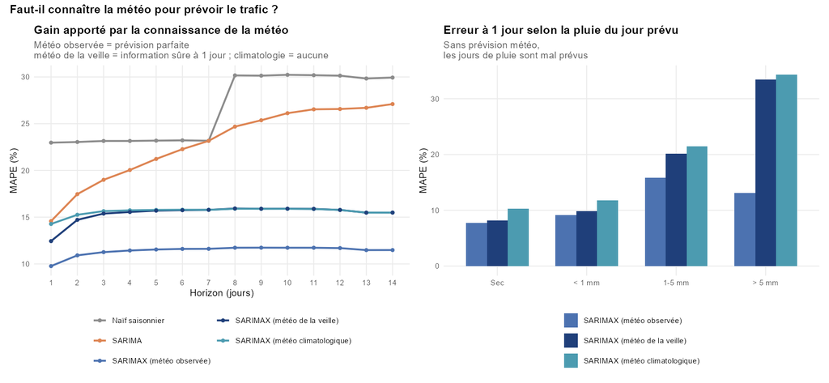

SARIMAX avec météo observée ou climatologique.

À 1 jour, l’erreur du SARIMAX passe de 9,8 % avec la météo observée à 14,3 % avec la météo climatologique. À 7 jours, elle passe de 11,6 % à 15,8 %. La version « météo de la veille » fait 12,4 % à 1 jour : un peu mieux que la climatologie, mais loin de la météo observée, ce que la CCF laissait prévoir. Une vraie prévision météo, fiable à 2-3 jours puis de moins en moins, se situe entre les deux extrêmes : **la qualité de la prévision du trafic dépend d’abord de celle de la prévision de pluie**.

Le SARIMA doublement différencié (d = D = 1) fait 22,9 % en moyenne, autant que le SARIMA avec d = 0, D = 1 (22,9 %) : différencier une fois de plus n’apporte rien, comme l’annonçait la racine unité de son MA. Le lissage simple et Holt, qui ignorent la semaine, sont les plus mauvais : 32,0 % et 33,3 %.

## 10.4 Intervalles de prévision

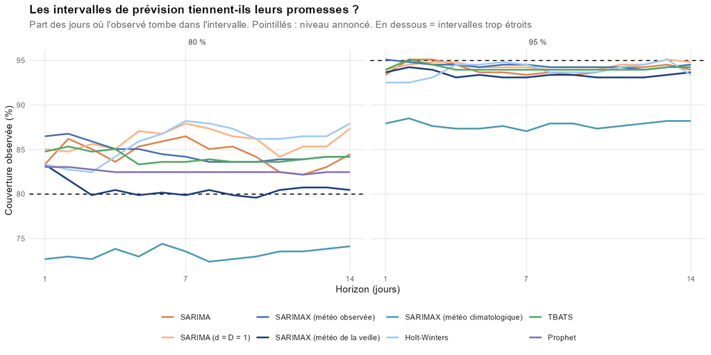

Couverture réelle des intervalles à 80 % et 95 %.

Les intervalles à 95 % du SARIMA, du SARIMAX et de TBATS sont **bien calibrés** (environ 94 % de couverture). Les intervalles à 80 % sont **trop larges** (84 à 87 %). C’est la marque des queues épaisses vues dans le diagnostic : la plupart des erreurs sont plus petites qu’une loi normale ne le prévoit, mais les rares grosses erreurs sont plus grosses. Avec la météo climatologique, les intervalles sont trop étroits (88 % à 95 %) : ils ignorent l’incertitude sur la météo elle-même.

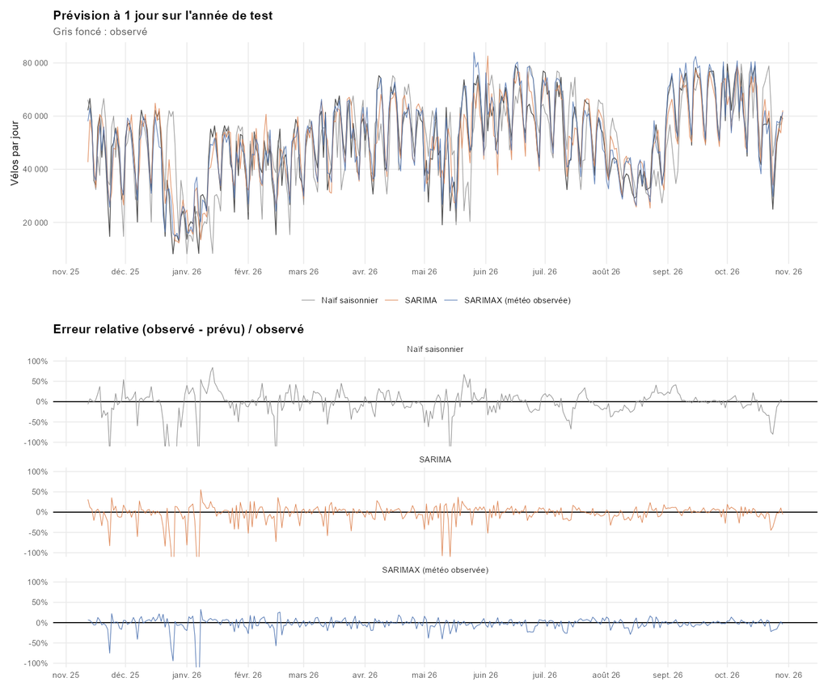

Prévisions à 1 jour sur l’année de test et erreurs relatives.

[figure not shown]

Erreurs à 1 jour du meilleur modèle, par jour, par mois, et les 10 pires jours.

Les erreurs sont plus fortes le week-end, dont le trafic de loisir est plus sensible au temps qu’il fait, et en décembre-janvier. Les deux pires jours, les 6 et 7 janvier 2026, sont des journées de gel avec précipitations (neige ou verglas probables) : le trafic tombe à 8 306 vélos. Le modèle, qui ne connaît que la température moyenne et la hauteur de pluie, ne peut pas anticiper un tel effondrement. Une variable « neige / verglas » serait la première amélioration.

## 10.5 Prévision des 14 prochains jours

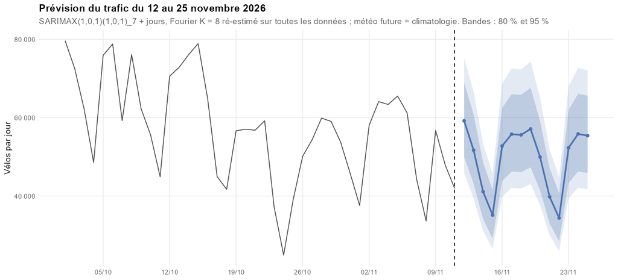

Prévision du 12 au 25 novembre 2026.

Le SARIMAX ré-estimé sur toutes les données prévoit en moyenne 49 729 vélos par jour du 12 au 25 novembre 2026. Les intervalles sont larges, car la météo de ces jours est inconnue (climatologie).

# 11 Conclusion

1. **Ce qui fait le trafic cyclable parisien.** C’est d’abord le **calendrier** : la semaine de travail, la saison, les fériés et les vacances expliquent ensemble environ 70 % de la variance. Vient ensuite la **météo** (13 %), surtout la pluie. La tendance, forte sur huit ans, pèse peu au jour le jour. Les événements exceptionnels ont des effets considérables mais ponctuels : grève ×2, confinement ÷5.
2. **Ce que la méthodologie a révélé.**
   - Le passage au log est justifié par la relation entre niveau et dispersion.
   - La série est stationnaire autour d’une tendance.
   - La racine unité du MA saisonnier montre que la semaine est déterministe, ce qui conduit à un SARIMAX sans différence saisonnière.
   - Les résidus sont non gaussiens et présentent un effet ARCH lié aux fêtes.
3. **Prévoir à quelques jours est possible.**
   - Avec une bonne prévision météo, l’erreur est d’environ 10 % à 1 jour (SARIMAX) et 11 % à 14 jours (Prophet), contre 23 à 30 % pour la prévision naïve.
   - Sans prévision météo, elle remonte à environ 16 %.

**Limites et pistes.**

- Le panel de 27 compteurs historiques sous-estime peut-être la croissance sur les nouveaux axes.
- Certains jours restent mal pris en compte : réveillons, journée sans voiture, grèves de 2023. Des indicatrices supplémentaires les traiteraient.
- Les intervalles de prévision à 80 % sont trop larges, conséquence des queues épaisses.
- La neige et le verglas manquent parmi les variables.
- Une extension naturelle est le modèle horaire, avec deux saisonnalités imbriquées de 24 h et 168 h.

# Annexe : méthodes envisagées mais non retenues

- **Tendance logistique de Prophet** : elle suppose une saturation connue (une capacité maximale). Rien n’indique de plafond du trafic cyclable sur la période, et fixer un plafond arbitraire serait une hypothèse non justifiée.
- **Stationnarité asymptotique sur ℕ, processus anticipatifs** : ce sont des résultats théoriques sur des processus simulés depuis $X_0$. Une série observée ne permet pas de les illustrer sans artifice.

# Annexe : reproductibilité

Lancer, depuis `projet_velo/`, les scripts `R/01_import.R` à `R/10_evaluation.R` dans l’ordre, puis `quarto render rapport/rapport.qmd`. Les figures sont dans `figures/`, les tableaux de résultats dans `resultats/`.